# GWP 1

$\Large\textbf{Heteroskedascity}$
$\textbf{Definition}$
$$ \mathrm{Var}(e) = \begin{pmatrix} \delta_{1}^{2} & 0 & 0 & \cdots & 0 \\ 0 & \delta_{2}^{2} & 0 & \cdots & 0 \\ 0 & 0 & \delta_{3} ^{2} & \cdots & 0 \\ \vdots & \vdots & \vdots & \ddots & \vdots \\ 0 & 0 & 0 & \cdots & \delta_{n} ^{2} \\ \end{pmatrix} $$ where $\mathrm{Var}(e)$ is variance of the residual and $\delta_{1}^{2} \neq \delta_{2}^{2} \neq \delta_{3}^{2} \neq \cdots \neq \delta_{n}^{2}$

$\textbf{Description}$  
Heteroskedascity in regression model occur when the variance of the residual (different between predicted value and observed value) is not constant. This would violate one of the most important assumptions of the OLS.

$\textbf{Demonstration}$
The model will clarify the relationship between engine size of a car and fuel consumption on the highway. The OLS model is as follows:
$$ Y_{i} = \beta_{0} + \beta_{1}\times X_{i} + \varepsilon_{i} $$
where:
$Y_{i}$ is fuel consumption on the highway,
$X_{i}$ is size of car's engine,
$\beta_{0}$ is the intercept,
$\beta_{1}$ is the coefficient or slope of regression line,
$\varepsilon_{i}$ is the error term of model
Input data is taken from the following website: https://open.canada.ca/data/en/dataset/98f1a129-f628-4ce4-b24d-6f16bf24dd64

```python
import matplotlib.pyplot as plt
import numpy as np
import pandas as pd
import statsmodels.api as sm
import statsmodels.formula.api as smf
import statsmodels.stats.api as sms
import scipy.stats as stats
import seaborn as sns
import pylab
from scipy.stats import kurtosis, skewnorm

plt.rcParams["figure.figsize"] = (9, 4)
```

```python
data_set = pd.read_csv("Data.csv")
```

```python
data_set.head()
```

|  | MODEL | MAKE | MODEL.1 | VEHICLE CLASS | ES | CYLINDERS | TRANSMISSION | FUEL | CITY | HWY | COMB | COMB (mpg) | (g/km) |
| --- | --- | --- | --- | --- | --- | --- | --- | --- | --- | --- | --- | --- | --- |
| 0 | 2015 | ACURA | ILX | COMPACT | 2.0 | 4 | AS5 | Z | 9.7 | 6.7 | 8.3 | 34 | 191 |
| 1 | 2015 | ACURA | ILX | COMPACT | 2.4 | 4 | M6 | Z | 10.8 | 7.4 | 9.3 | 30 | 214 |
| 2 | 2015 | ACURA | ILX HYBRID | COMPACT | 1.5 | 4 | AV7 | Z | 6.0 | 6.1 | 6.1 | 46 | 140 |
| 3 | 2015 | ACURA | MDX SH-AWD | SUV - SMALL | 3.5 | 6 | AS6 | Z | 12.7 | 9.1 | 11.1 | 25 | 255 |
| 4 | 2015 | ACURA | RDX AWD | SUV - SMALL | 3.5 | 6 | AS6 | Z | 12.1 | 8.7 | 10.6 | 27 | 244 |

```python
model_1 = smf.ols("HWY ~ ES", data=data_set).fit()
model_1.summary()
```

OLS Regression Results

| Dep. Variable: | HWY | R-squared: | 0.591 |
| --- | --- | --- | --- |
| Model: | OLS | Adj. R-squared: | 0.591 |
| Method: | Least Squares | F-statistic: | 1635. |
| Date: | Mon, 13 Mar 2023 | Prob (F-statistic): | 7.92e-222 |
| Time: | 17:42:40 | Log-Likelihood: | -2021.9 |
| No. Observations: | 1132 | AIC: | 4048. |
| Df Residuals: | 1130 | BIC: | 4058. |
| Df Model: | 1 |  |  |
| Covariance Type: | nonrobust |  |  |

|  | coef | std err | t | P>\|t\| | [0.025 | 0.975] |
| --- | --- | --- | --- | --- | --- | --- |
| Intercept | 4.8625 | 0.109 | 44.455 | 0.000 | 4.648 | 5.077 |
| ES | 1.2805 | 0.032 | 40.438 | 0.000 | 1.218 | 1.343 |

| Omnibus: | 311.597 | Durbin-Watson: | 1.316 |
| --- | --- | --- | --- |
| Prob(Omnibus): | 0.000 | Jarque-Bera (JB): | 1229.525 |
| Skew: | 1.267 | Prob(JB): | 1.03e-267 |
| Kurtosis: | 7.433 | Cond. No. | 9.43 |

Notes:  
[1] Standard Errors assume that the covariance matrix of the errors is correctly specified.

$\textbf{Diagram}$

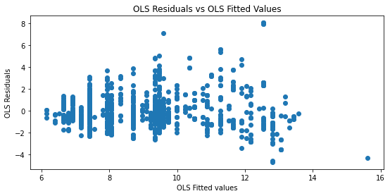

```python
model_fitted_y = model_1.fittedvalues
model_resid_y = model_1.resid
plt.scatter(x=model_fitted_y, y=model_resid_y)
plt.title("OLS Residuals vs OLS Fitted Values")
plt.xlabel("OLS Fitted values")
plt.ylabel("OLS Residuals")
plt.show()
```

As you can see in the chart above, the graph shows a conical or megaphone pattern. It implied that, when fitted values increase, the variance of residual increases or heteroskedasticity exists.

$\textbf{Diagnosis}$

```python
# Breusch-Pagan Test
name = ["Lagrange multiplier statistic", "p-value", "f-value", "f p-value"]
test = sms.het_breuschpagan(model_1.resid, model_1.model.exog)
pd.DataFrame(test, index=name, columns=[""])
```

| Lagrange multiplier statistic | 9.238646e+01 |
| --- | --- |
| p-value | 7.130013e-22 |
| f-value | 1.004188e+02 |
| f p-value | 1.058317e-22 |

The Breush-Pagan Test is a method to test the heteroskedasticity of the model. When p-value < 0.05, it is possible to reject the hypothesis $H_{0}$: Homoskedasticity exists, or in other words, the model exists with heteroskedasticity.

$\textbf{Damage}$

There are two main reasons to explain why we should correct heteroskedasticity in the model:

If heteroscedasticity exists, the OLS estimators are inefficient because alternate estimators with smaller variances of the regression coefficients that are still unbiased can be found.

If there is heteroscedasticity, the estimators of the standard errors of the regression coefficients are frequently less than reality, giving a false sense of the accuracy of the regression coefficients.

$\textbf{Direction}$

One of the following methods can be used to adjust heteroskedasticity in regression analysis:  
**1.** Make a change to the dependant variable: One method for dealing with heteroskedasticity is to alter the dependent variable in some way. Taking the log of the dependent variable is a typical transformation. This adjustment can assist decrease the data's oscillations between large and small values.  
**2.** Change the definition of the dependent variable: Another method for dealing with heteroskedasticity is to rename the dependent variable. If you wish to anticipate spending on a product, for example, you may use the spend-to-total income ratio rather than the exact spend amount.  
**3.** Make use of weighted regression: Another method for dealing with heteroskedasticity is to employ weighted regression, which assigns weights to data based on their degree of confidence. Weights will be assigned to observations with big mistakes and vice versa.

$\Large\textbf{Kurtosis}$

$\textbf{Definition}$
Kurtosis formula: $$\text{Kurtosis}=\sum_{i=1}^{n}\frac{(X_{i}-\bar{X})^4/N}{s^{4}}$$ where $\bar{X}$ is the mean of $\text{X}$ and $\text{s}$ is the standard deviation of $\text{X}$

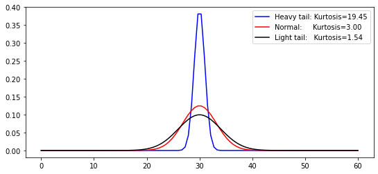

```python
x = np.linspace(0, 60, 100)
y1 = stats.norm.pdf(x, loc=30, scale=1)
y2 = stats.norm.pdf(x, loc=30, scale=3.194)
y3 = stats.norm.pdf(x, loc=30, scale=4)

# Plot each distribution
plt.plot(x, y1, c="b", label="Heavy tail: Kurtosis={:.2f}".format(kurtosis(y1)))
plt.plot(x, y2, c="r", label="Normal:     Kurtosis={:.2f}".format(kurtosis(y2)))
plt.plot(x, y3, c="k", label="Light tail:   Kurtosis={:.2f}".format(kurtosis(y3)))
plt.legend()
plt.show()
```

$\textbf{Demonstration}$  
One of the OLS model's assumptions is that the error term has a normal distribution with mean zero and constant variance. This signifies that the residuals have no outliers or skewness. This assumption will be tested using data from model_1.

```python
res=model_1.resid
res.describe()
```

```
count    1.132000e+03
mean    -7.580901e-15
std      1.444264e+00
min     -4.701541e+00
25%     -8.506335e-01
50%     -2.235079e-01
75%      6.277174e-01
max      8.054556e+00
dtype: float64
```

```python
res.kurtosis()
```

```
4.45793839221202
```

$\textbf{Diagram}$

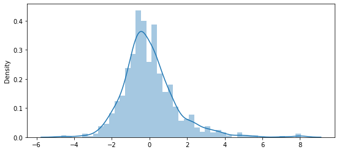

```python
sns.distplot(res)
```

Based on the chart above, it is difficult to determine whether the distribution has kurtosis = 3 or not. So we need to double check in the following 2 ways.

$\textbf{Diagnosis}$

Method 1: Use Q-Q Plot Based on the graph, it can be seen that the residuals are not normally distributed. It takes the form of a curve instead of a straight line, and this curve shows that the distribution has more extreme values than the normal distribution.

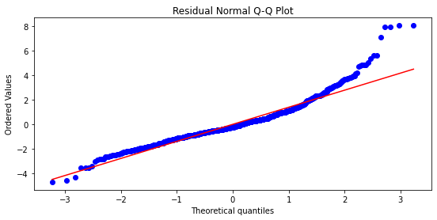

```python
stats.probplot(model_1.resid, dist="norm", plot=pylab)
plt.title("Residual Normal Q-Q Plot")
```

Method 2: Use Shapiro-Wilk test. We can use Shapiro-Wilk test to check if the distribution is normal or not. If p-value > 0.05, we cannot reject the hypothesis that the distribution is normally distributed. If p-value < 0.05, we reject the hypothesis that the distribution is normally distributed.

```python
shapiro_test_res = stats.shapiro(res)
print("Residual")
print("Shapiro W: {0} \nShapiro pvalue {1}".format(shapiro_test_res.statistic, shapiro_test_res.pvalue))
```

```
Residual
Shapiro W: 0.9252585768699646
Shapiro pvalue 2.7806018467276274e-23
```

Because p-value <0.05, we can conclude that the distribution is not normally distributed and the kurtosis in statistic is 4.45 so that the distribution has leptokurtic.

$\textbf{Damage}$

Excess kurtosis in the OLS error term indicates that there are more outliers or extreme values in the residuals than would be expected under normality. This might imply that several OLS assumptions, such as homoscedasticity, linearity, or error independence, have been broken. Excess kurtosis may also have an impact on the validity of several statistical tests that rely on normality, such as t-tests and F-tests.

$\textbf{Direction}$

If the OLS residual has too much kurtosis, you can try different solutions depending on what causes the problem. Some possible solutions are:

**1.** Changing the dependent variable or the independent variables with some functions to make their distributions less skewed and less kurtotic. For example, you can use log, square root, or Box-Cox functions.  
**2.** Using other regression methods that are not affected by outliers or extreme values. For example, you can use M-estimators, MM-estimators, or least trimmed squares.  
**3.** Using GLM that can handle different error distributions than normal. For example, you can use a t-distribution or a gamma distribution to model errors with heavy tails.  
**4.** Using bootstrapping methods that do not need normality assumptions and create confidence intervals and p-values by resampling techniques.